# Generate the temporal abundance variation of sampled population

Romain Lorrilliere

2023-02-28

# One population sampled

## One population dynamic

We generate the abundance variation of one population following an exponential function. Thus the population abundance at t time N_t is only according to : N(t+1) = exp(r) * N(t) N0

For example : r in =-0.01 and N0 = 1000 and with demographic stochasticity simulated thanks a pick up in a Poisson distribution.

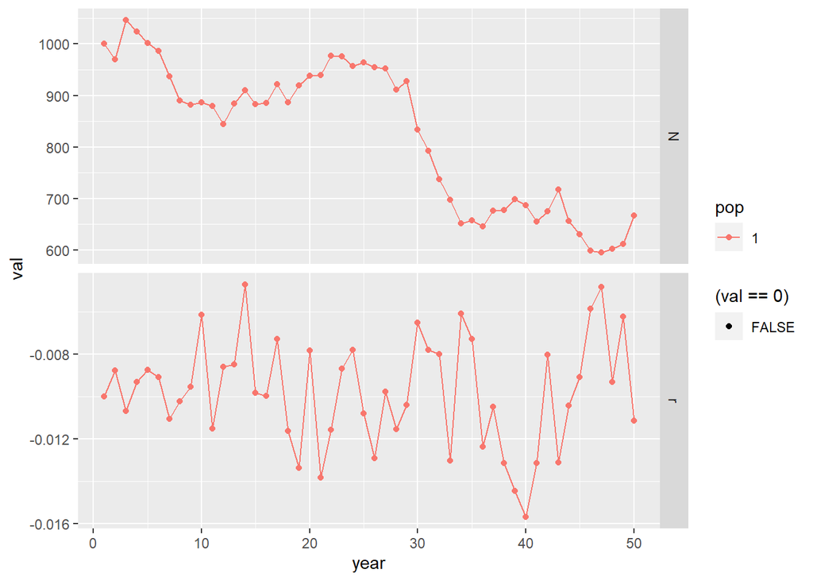

## Sampling

### Duration

We model the sampled abundance variation according to a survey that starts in year 5 for a 10 years duration. In this example, the survey is done yearly (completeness = 1), and the abundances recorded are the absolute abundance.

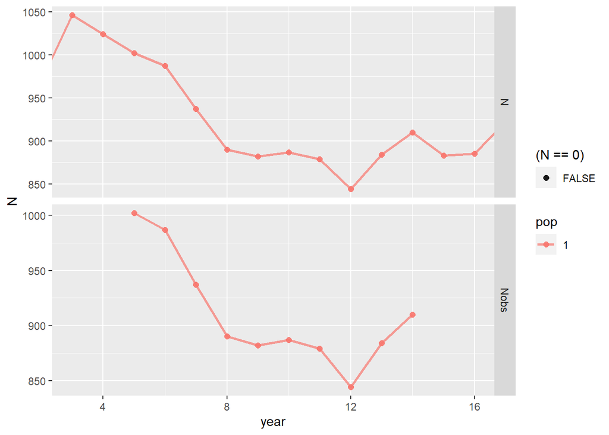

### Completness

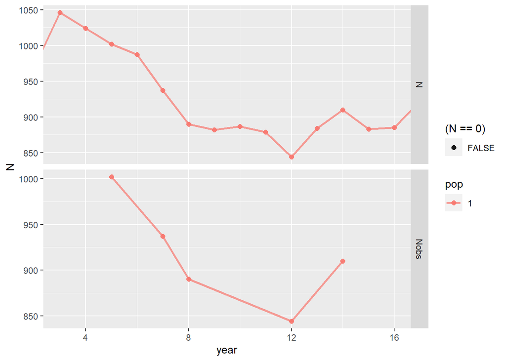

### Observation probability

Finally, most of the surveys on the field do not provide absolute abundance but, more often, relative abundance due to the observation probability lesser than 1.  
For example, here, the observation probability = 0.01.

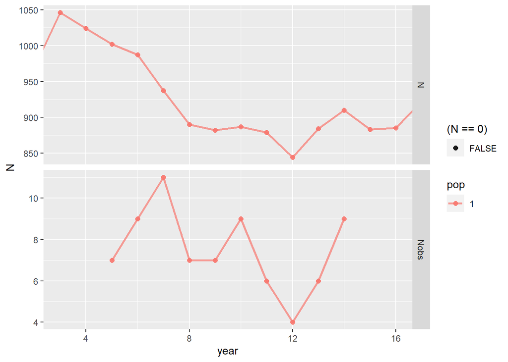

# Several populations

## the populations

for example for 9 populations:

N0 in N(mean=1000,sd = 100) and r in N(mean=N(mean = -0.05,sd = 0.02),sd = 0.0025)

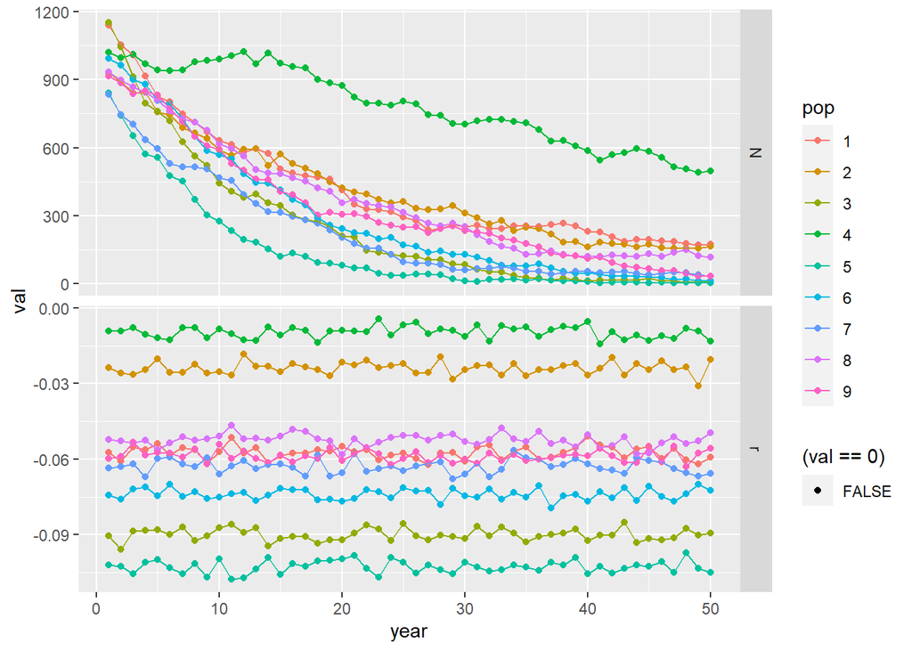

## Samples

### Same samples

We could simulate the data provide by a same protocole.

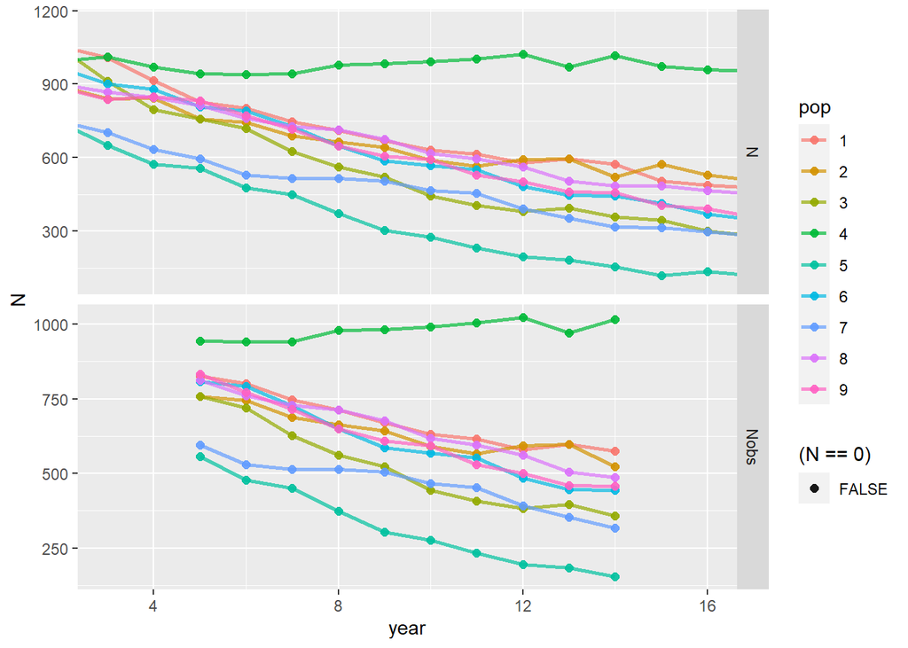

### Different samples

Finally, all populations are surveyed by an indepent and unique protocole. for all survey the paramters randimezed according to :

- year of start = N(mean=5, sd= 5)
- duration of survey = N(mean=10, sd= 10)
- completness = N(mean=0.5, sd= 0.5) only value between 0 and 1.
- probability of observation = N(mean=0.05, sd= 0.05)only value between 0 and 1.

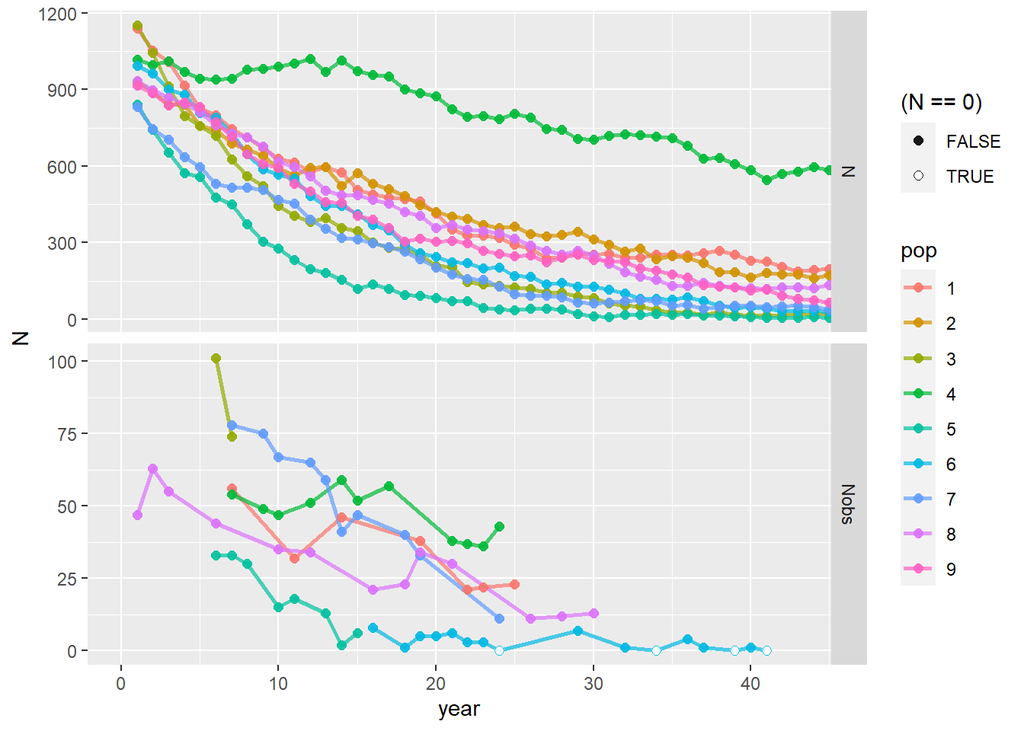